# Analysis & plots for paper: Seasonal habitat use and diel vertical migration in female spurdog in Nordic waters, Movement Ecology

### 5.5.2 Vertical speeds

Figure 4B,E: High vertical speeds during dusk and dawn also indicate nDVM and likely feeding behaviour, as they follow the prey up or down and make use of less organised swarms.

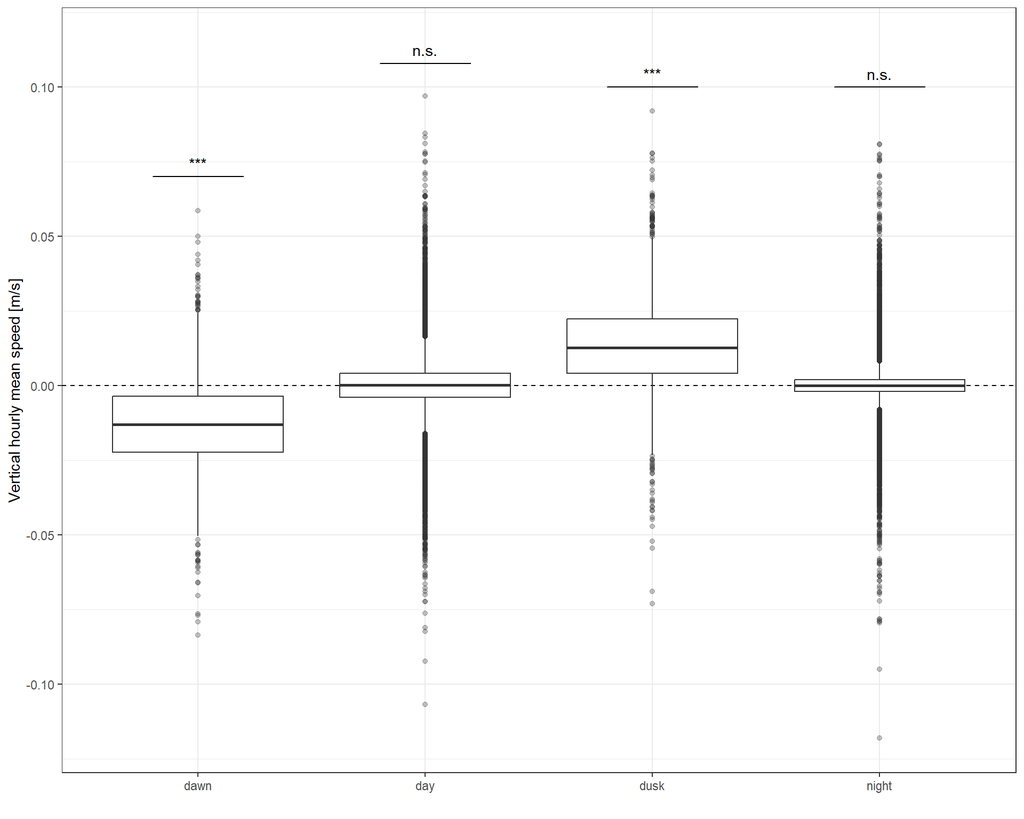

```r
# hourly mean vertical speed by DVM
p4 <- ggplot(data = hdata %>% filter(DVM == "DVM"))+ # added filter (not in saved version)
  geom_hline(yintercept=0, linetype='dashed')+
  geom_boxplot(aes(y = Vertical_speed_mean , x = daynightduskdawn.naut), outlier.alpha = 0.3)+
  labs(y = "Vertical hourly mean speed [m/s]",
       x = "")+
  geom_signif(aes(y = Vertical_speed_mean , x = daynightduskdawn.naut, group = daynightduskdawn.naut),
              xmin = c(0.8, 1.8,2.8,3.8), xmax = c(1.2,2.2,3.2,4.2),
              y_position = c(0.07, 0.108, 0.1,0.1),
              annotation = c("***", "n.s.","***", "n.s."), tip_length = 0) +
  theme_bw()+
  expand_limits(y = 0.115)
p4
```

Mean hourly vertical speeds at both dawn and dusk are significantly different from zero.

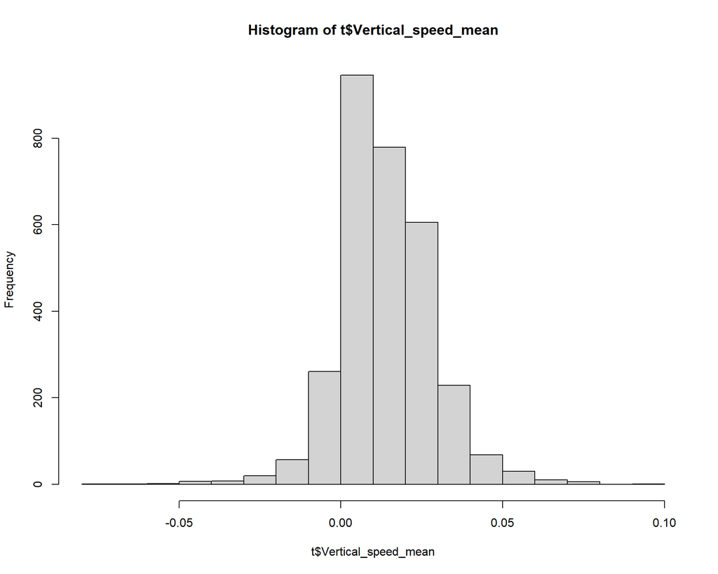

```r
t <- hdata %>% filter(daynightduskdawn.naut == "dusk" & DVM == "DVM")
hist(t$Vertical_speed_mean)
```

```r
t.test(t$Vertical_speed_mean)
```

```
#>
#>  One Sample t-test
#>
#> data:  t$Vertical_speed_mean
#> t = 52.237, df = 3030, p-value < 2.2e-16
#> alternative hypothesis: true mean is not equal to 0
#> 95 percent confidence interval:
#>  0.01326251 0.01429697
#> sample estimates:
#>  mean of x
#> 0.01377974
```

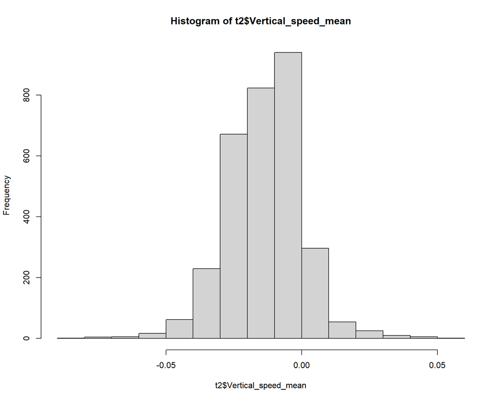

```r
t2 <- hdata %>% filter(daynightduskdawn.naut == "dawn"& DVM == "DVM")
hist(t2$Vertical_speed_mean)
```

```r
t.test(t2$Vertical_speed_mean)
```

```
#>
#>  One Sample t-test
#>
#> data:  t2$Vertical_speed_mean
#> t = -54.407, df = 3140, p-value < 2.2e-16
#> alternative hypothesis: true mean is not equal to 0
#> 95 percent confidence interval:
#>  -0.01385255 -0.01288884
#> sample estimates:
#>  mean of x
#> -0.0133707
```

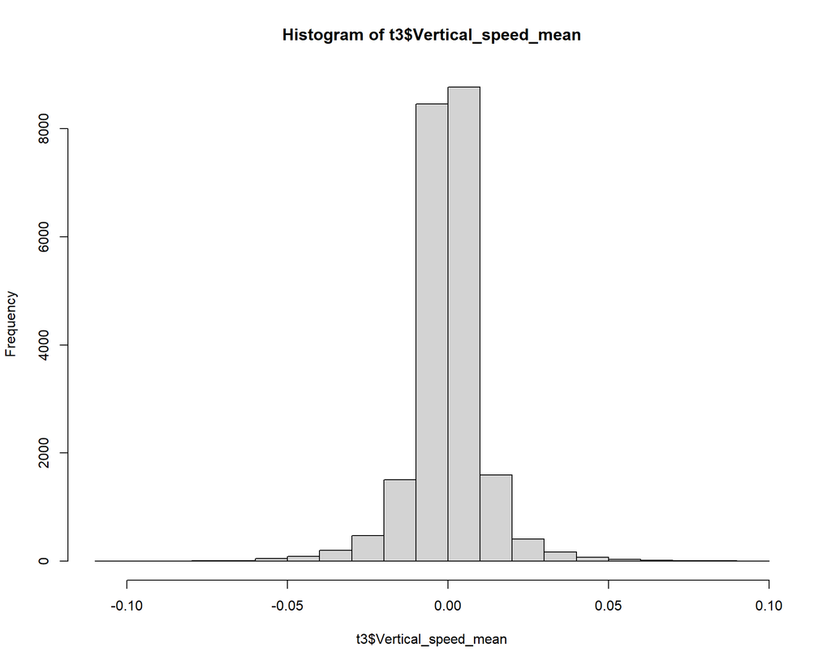

```r
t3 <- hdata %>% filter(daynightduskdawn.naut == "day" & DVM == "DVM")
hist(t3$Vertical_speed_mean)
```

```r
t.test(t3$Vertical_speed_mean)
```

```
#>
#>  One Sample t-test
#>
#> data:  t3$Vertical_speed_mean
#> t = 0.29097, df = 21855, p-value = 0.7711
#> alternative hypothesis: true mean is not equal to 0
#> 95 percent confidence interval:
#>  -0.0001246674  0.0001681338
#> sample estimates:
#>    mean of x
#> 2.173316e-05
```

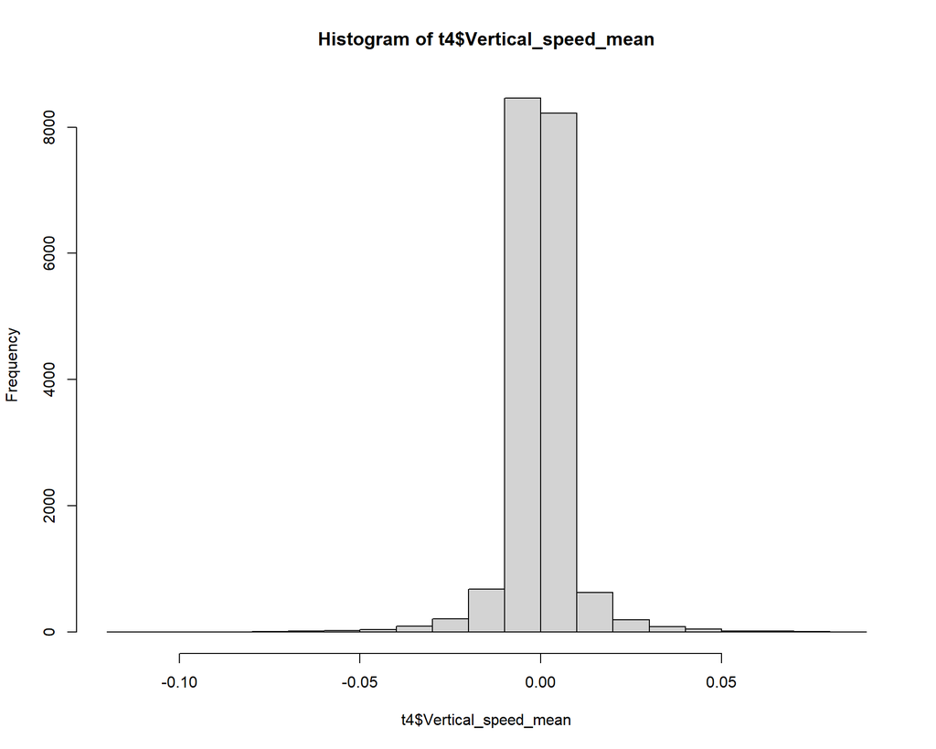

```r
t4 <- hdata %>% filter(daynightduskdawn.naut == "night" & DVM == "DVM")
hist(t4$Vertical_speed_mean)
```

```r
t.test(t4$Vertical_speed_mean)
```

```
#>
#>  One Sample t-test
#>
#> data:  t4$Vertical_speed_mean
#> t = -0.31487, df = 18718, p-value = 0.7529
#> alternative hypothesis: true mean is not equal to 0
#> 95 percent confidence interval:
#>  -0.0001430810  0.0001034748
#> sample estimates:
#>     mean of x
#> -1.980311e-05
```

For one tag (shark 15)

```r
p5 <- ggplot(data = hdata %>%
               filter(sharkID ==s) %>%
               mutate(Time = hms::hms(second(DateTime),minute(DateTime),hour(DateTime)),
                      sunrise = hms::hms(second(sunrise),minute(sunrise),hour(sunrise)),
                      sunset = hms::hms(second(sunset),minute(sunset),hour(sunset)),
                      nautdawn = hms::hms(second(dawn.naut),minute(dawn.naut),hour(dawn.naut)),
                      nautdusk = hms::hms(second(dusk.naut),minute(dusk.naut),hour(dusk.naut))) %>%
                      #ensure there are no beginning nights/days - avoid vertical line
               mutate(nautdawn = replace(nautdawn, is.na(nautdusk), NA),
                      nautdusk = replace(nautdusk, is.na(nautdawn), NA)))+
  geom_tile(aes(y=Time, x=Date, fill=Vertical_speed_mean))+
  scale_fill_gradient2(low = "indianred3", mid = "white", high = "royalblue2", name= "Speed [m/s]")+
  scale_x_date(date_breaks = "1 month",date_labels = "%b", expand = c(0,0))+
  scale_y_time(breaks = scales::breaks_width("2 hours"), labels = scales::label_time("%H:%M"), expand = c(0,0))+
  geom_line(aes(x = Date, y = sunrise), col = "grey20")+
  geom_line(aes(x = Date, y = sunset), col = "grey20")+
  geom_line(aes(x = Date, y = nautdawn), col = "grey50", linetype = "dashed")+
  geom_line(aes(x = Date, y = nautdusk), col = "grey50", linetype = "dashed")+
  theme_bw()+
  labs(x = "", y = "Time of day [hrs]")
```

### 5.5.3 composite figure 4

```r
layout <- "\nAABBB\nAACCC\nDDEEE\n"
p <- p1+p2+p3+p4+p5 +
  plot_layout(design = layout) +
  plot_annotation(tag_levels =list(c("A", "C", "D", "B", "E")))
ggsave(p, filename = paste0("plots/spurdog/paper/fig4_nDVM.png"), width = 30, height = 25, units = "cm")
```

### 5.5.4 Individal differences

Figure S11: Inter-individual differences in median depth distributions for day and night during as significant classified diel vertical migration (DVM). Results from a Wilcoxon signed rank test shown for each shark. Violin plots in grey represent the full distribution of the data. Boxplots show median and lower and upper quartiles with whiskers extending to 1.5*IQR.

```r
t1 <- mdata %>% filter(DVM == "DVM") %>% group_by(Date, sharkID, daynight) %>% summarise(Depth_median = median(Depth_median))
t2 <- mdata %>% filter(DVM == "DVM") %>% group_by(Date, sharkID, daynight) %>% summarise(Depth_median = median(Depth_median)) %>% group_by(Date, sharkID) %>% summarise(n = n())
t <- left_join(t1, t2, by = c("Date", "sharkID")) %>% filter(n == 2) %>% ungroup()

for(s in sharks){
  ts <- t %>% filter(sharkID == s)#
  assign(
    paste0("p",s),
    ggstatsplot::ggwithinstats( # paired samples
      data = ts,
      x = daynight,
      y = Depth_median,
      type = "nonparametric", # for wilcoxon
      boxplot.args = list(width = 0.15, fill = "turquoise4", alpha = 0.5),
      violin.args = list(alpha = 0, colour = "grey70"),
      point.args = list(alpha = 0),# to remove points
      point.path = F,
      ggtheme = theme_bw(),
      centrality.plotting = F,
      centrality.path = F,
      centrality.point.args = list(alpha = 0),
      results.subtitle =T,
      xlab = "",
      ylab  = "Depth [m]",
      title  = paste0("Shark ", s)
    )
  )
}
p1 <- p1 + scale_y_reverse()+ theme(plot.subtitle=element_text(size=5.5, hjust=0, face="italic", color="black"))
p2 <- p2 + scale_y_reverse()+theme(plot.subtitle=element_text(size=5.5, hjust=0, face="italic", color="black"))
p3 <- p3 + scale_y_reverse()+theme(plot.subtitle=element_text(size=5.5, hjust=0, face="italic", color="black"))
p4 <- p4 + scale_y_reverse()+theme(plot.subtitle=element_text(size=5.5, hjust=0, face="italic", color="black"))
p5 <- p5 + scale_y_reverse()+theme(plot.subtitle=element_text(size=5.5, hjust=0, face="italic", color="black"))
p6 <- p6 + scale_y_reverse()+theme(plot.subtitle=element_text(size=5.5, hjust=0, face="italic", color="black"))
p7 <- p7 + scale_y_reverse()+theme(plot.subtitle=element_text(size=5.5, hjust=0, face="italic", color="black"))
p8 <- p8 + scale_y_reverse()+theme(plot.subtitle=element_text(size=5.5, hjust=0, face="italic", color="black"))
p9 <- p9 + scale_y_reverse()+theme(plot.subtitle=element_text(size=5.5, hjust=0, face="italic", color="black"))
p10 <- p10 + scale_y_reverse()+theme(plot.subtitle=element_text(size=5.5, hjust=0, face="italic", color="black"))
p11 <- p11 + scale_y_reverse()+theme(plot.subtitle=element_text(size=5.5, hjust=0, face="italic", color="black"))
p12 <- p12 +  scale_y_reverse()+theme(plot.subtitle=element_text(size=5.5, hjust=0, face="italic", color="black"))
p13 <- p13 + scale_y_reverse()+theme(plot.subtitle=element_text(size=5.5, hjust=0, face="italic", color="black"))
p14 <- p14 + scale_y_reverse()+theme(plot.subtitle=element_text(size=5.5, hjust=0, face="italic", color="black"))
p15 <- p15 + scale_y_reverse()+theme(plot.subtitle=element_text(size=5.5, hjust=0, face="italic", color="black"))
p16 <- p16 +  scale_y_reverse()+theme(plot.subtitle=element_text(size=5.5, hjust=0, face="italic", color="black"))
p17 <- p17 +  scale_y_reverse()+theme(plot.subtitle=element_text(size=5.5, hjust=0, face="italic", color="black"))
p18 <- p18 +  scale_y_reverse()+theme(plot.subtitle=element_text(size=5.5, hjust=0, face="italic", color="black"))
p19 <- p19 +  scale_y_reverse()+theme(plot.subtitle=element_text(size=5.5, hjust=0, face="italic", color="black"))
## combining the individual plots into a single plot
p <- ggstatsplot::combine_plots(
  plotlist = list(p1, p2, p3, p4, p5,p6,p7,p8,p9,p10,p11,p12,p13,p14,p15,p16,p17,p18,p19),
  plotgrid.args = list(nrow = 5)
  # annotation.args = list(title = "Individual hourly fast starts over day and night")
)
ggsave(p, filename = paste0("plots/spurdog/supplement/fig11_Depth-Ind_DayNight.png"), width = 35, height = 40, units = "cm")
```

### 5.5.5 Boxplots over month

Figure S10: Hourly median depth used across all individuals for a given month. Medians and 25, 75% confidence intervals are shown. Number of sharks contributing to each monthly plot are indicated.

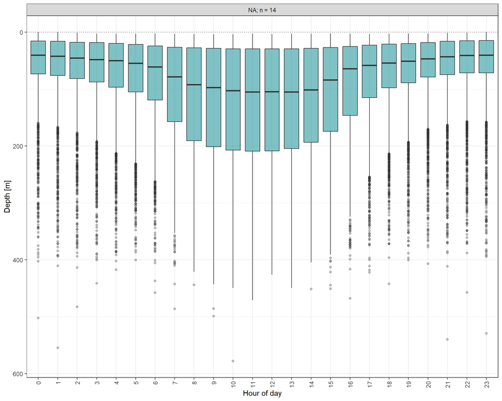

```r
n <- ddata %>% mutate(Month = factor(month(Date), levels = c(11:12,1:10))) %>% group_by(Month) %>% reframe(n = length(unique(sharkID)))

ggplot(data = hdata %>% mutate(Month = factor(lubridate::month(Date, label = T, abbr = T),
                            levels = c("Nov","Dec","Jan","Feb","Mar","Apr","May","Jun", "Jul", "Aug","Sep","Oct"))))+
  geom_hline(yintercept=0, linetype='dotted', colour = "grey30")+
  geom_boxplot(aes(x = as.factor(Hour) , y = Depth_median),outlier.alpha = 0.3, fill = "turquoise4", alpha = 0.5)+
  scale_y_reverse()+
  labs(x = "Hour of day", y = "Depth [m]")+
  guides(fill="none")+
  facet_wrap(~Month, labeller = stickylabeller::label_glue('{Month}; n = {n$n}'))+
  theme_bw()+
  theme(axis.text.x = element_text(angle = 90, vjust = 0.5, hjust=1))
```

```r
ggsave(filename = paste0("plots/spurdog/supplement/fig10_nDVM_perMonth.png"), width = 30, height = 20, units = "cm")
```

### 5.5.6 Timeseries

Figure 5: Seasonal differences in depth timeseries and number of fast starts. Exemplary data shown for sharks 2, 10, 15, and 19 for a week in January (winter, left) and June (early summer, right) based on 1-minute interval median depths (left y-axis) and temperatures (as colour) as well as hourly counts of fast starts (dark grey bars, right y-axis). Grey polygons mark night defined by sunset and sunrise and nautical dusk and dawn (sun 12° below horizon, winter only) around the tagging location. Note free y-axes and the x-axis in B showing data for May and not June due to lack of data for later month.

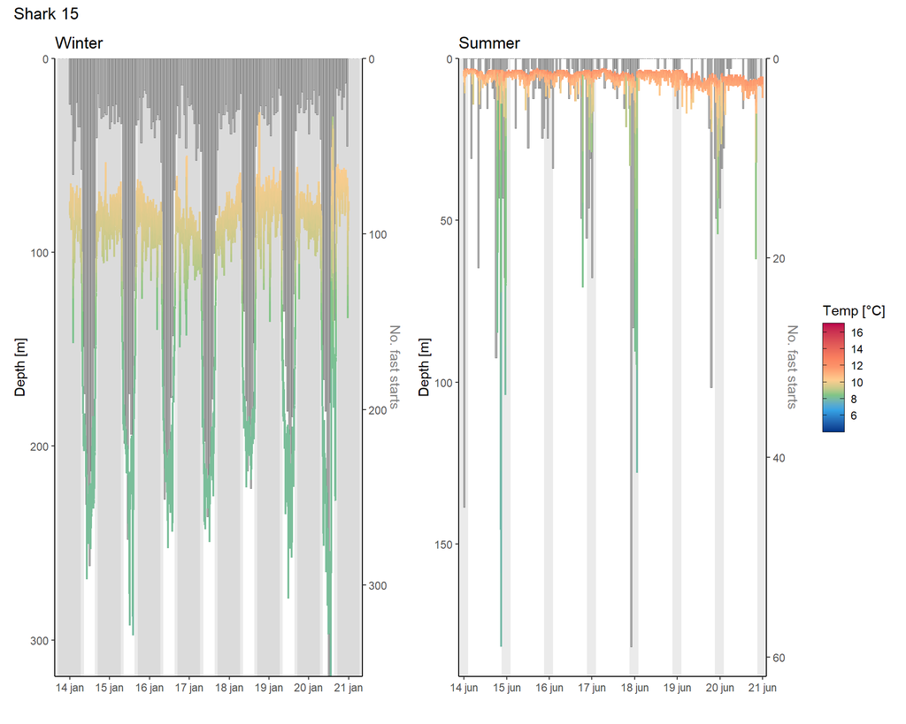

```r
p2_w  <- plot.DTAseries(mdata, hdata, shark = 2, from = "01-14", to = "01-21", season = "Winter", legend = F)
p10_w <- plot.DTAseries(mdata, hdata, shark = 10, from = "01-14", to = "01-21", season = "Winter", legend = F)
p15_w <- plot.DTAseries(mdata, hdata, shark = 15, from = "01-14", to = "01-21", season = "Winter", legend = F)
p19_w <- plot.DTAseries(mdata, hdata, shark = 19, from = "01-14", to = "01-21", season = "Winter", legend = F)

p2_s  <- plot.DTAseries(mdata, hdata, shark = 2, from = "05-14", to = "05-21", season = "Summer")
p10_s <- plot.DTAseries(mdata, hdata, shark = 10, from = "06-14", to = "06-21", season = "Summer")
p15_s <- plot.DTAseries(mdata, hdata, shark = 15, from = "06-14", to = "06-21", season = "Summer")
p19_s <- plot.DTAseries(mdata, hdata, shark = 19, from = "06-14", to = "06-21", season = "Summer")

p2  <- p2_w +p2_s + plot_annotation(title = paste0("Shark 2"))
p10 <- p10_w +p10_s + plot_annotation(title = paste0("Shark 10"))
p15 <- p15_w +p15_s + plot_annotation(title = paste0("Shark 15"))
p19 <- p19_w +p19_s + plot_annotation(title = paste0("Shark 19"))

# plot composite plot
p <- wrap_elements(p2)/wrap_elements(p10)/wrap_elements(p15)/wrap_elements(p19)
ggsave(plot = p, filename = paste0("plots/spurdog/paper/fig5_timeseries_wintersummer.png"),
       width = 30, height = 40, units = "cm")
p15
```

Monthly dynamics across all individuals for depth and activity across different hours of the day to act as a base for the illustrative figure on the poster.

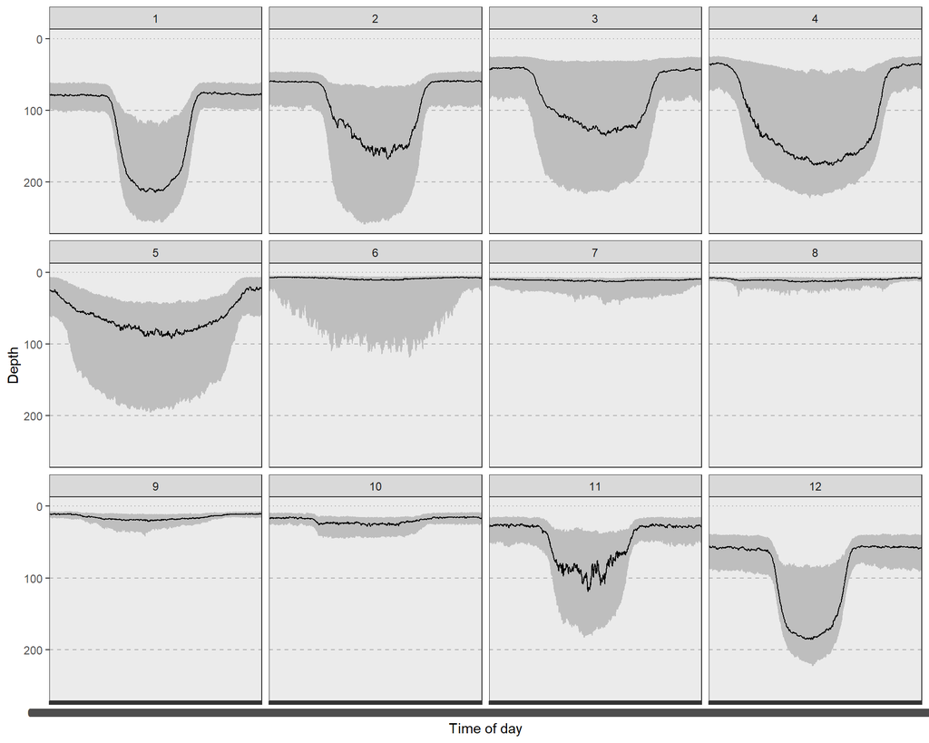

```r
# plots for illustrated fig on poster

# time series
t <- mdata %>%
  mutate(Time = format(DateTime, format = "%H:%M:%S")) %>%
  group_by(Time, Month) %>% summarise(D_m = median(Depth_median), D_l = quantile(Depth_median, 0.25),  D_u = quantile(Depth_median, 0.75))


ggplot(t, aes(x= Time, y=D_m, ymin = D_u, ymax= D_l, group = Month))+
  geom_hline(yintercept=0, linetype='dotted', colour = "grey70")+
  geom_hline(yintercept=c(100,200), linetype='dashed', colour = "grey70")+
  #geom_vline(xintercept=1, linetype='dotted', colour = "white")+
  geom_errorbar(width = 0.2, colour = "grey")+
  geom_line()+
  scale_y_reverse()+
  facet_wrap(~Month)+
  #scale_x_time(breaks = scales::breaks_width("2 hours"), labels = scales::label_time("%H:%M"), expand = c(0,0))+
  labs(y = "Depth", x = "Time of day")+
  theme_bw()
```

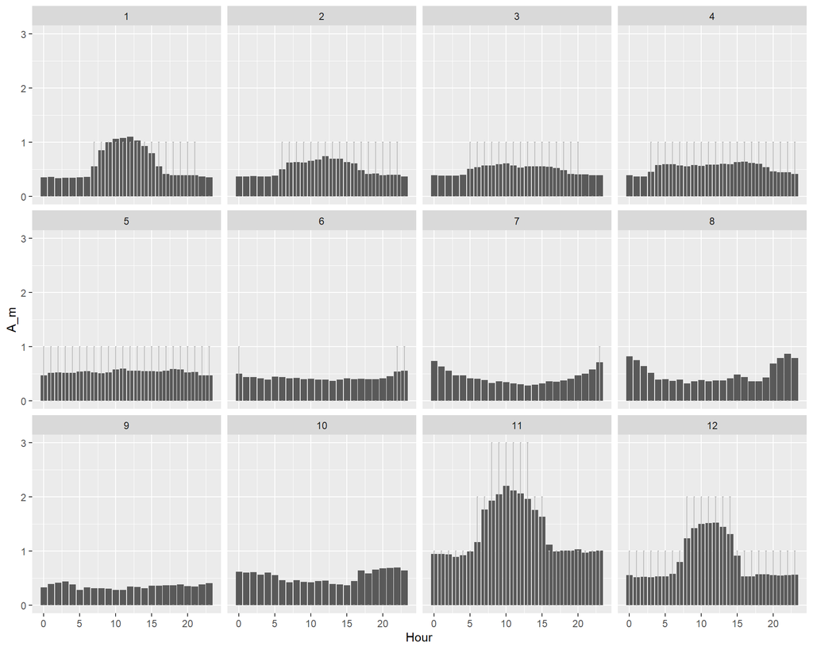

```r
ggsave(filename = paste0("plots/spurdog/poster/timeseries_months.png"),
       width = 35, height = 20, units = "cm")

# activity
a <- mdata %>%
  mutate(Time = format(DateTime, format = "%H:%M:%S")) %>%
  group_by(Hour, Month) %>% summarise(A_m = mean(FS95_cum), A_l = quantile(FS95_cum, 0.25),  A_u = quantile(FS95_cum, 0.75))

ggplot(a, aes(x= Hour, y=A_m, ymin = A_l, ymax= A_u, group = Month))+
  geom_bar(stat = "identity")+
  geom_errorbar(width = 0.2, colour = "grey")+
  facet_wrap(~Month)
```

```r
ggsave(filename = paste0("plots/spurdog/poster/activity_months.png"),
       width = 35, height = 20, units = "cm")
```

## 5.6 Activity patterns

### 5.6.1 Vertical speed stats

```r
range(mdata$Vertical_speed_mean)
```

```
#> [1] -1.258333  1.250000
```

```r
mean(mdata$Vertical_speed_mean)
```

```
#> [1] 1.012302e-06
```

```r
mean(hdata$Vertical_speed_abs_mean)
```

```
#> [1] 0.0241281
```

```r
quantile(mdata$Vertical_speed_mean, probs = c(0.25,0.75))
```

```
#>         25%         75%
#> -0.01666667  0.01666667
```

```r
thresh <- quantile(abs(mdata$Vertical_speed_mean), probs = 0.95)

t <- mdata %>% filter(abs(Vertical_speed_mean) > thresh)
table(t$Month)
```

```
#>
#>     1     2     3     4     5     6     7     8     9    10    11    12
#> 39261 29397 29755 31680 46114 21186 12488  8745 11835 17082 31631 42509
```

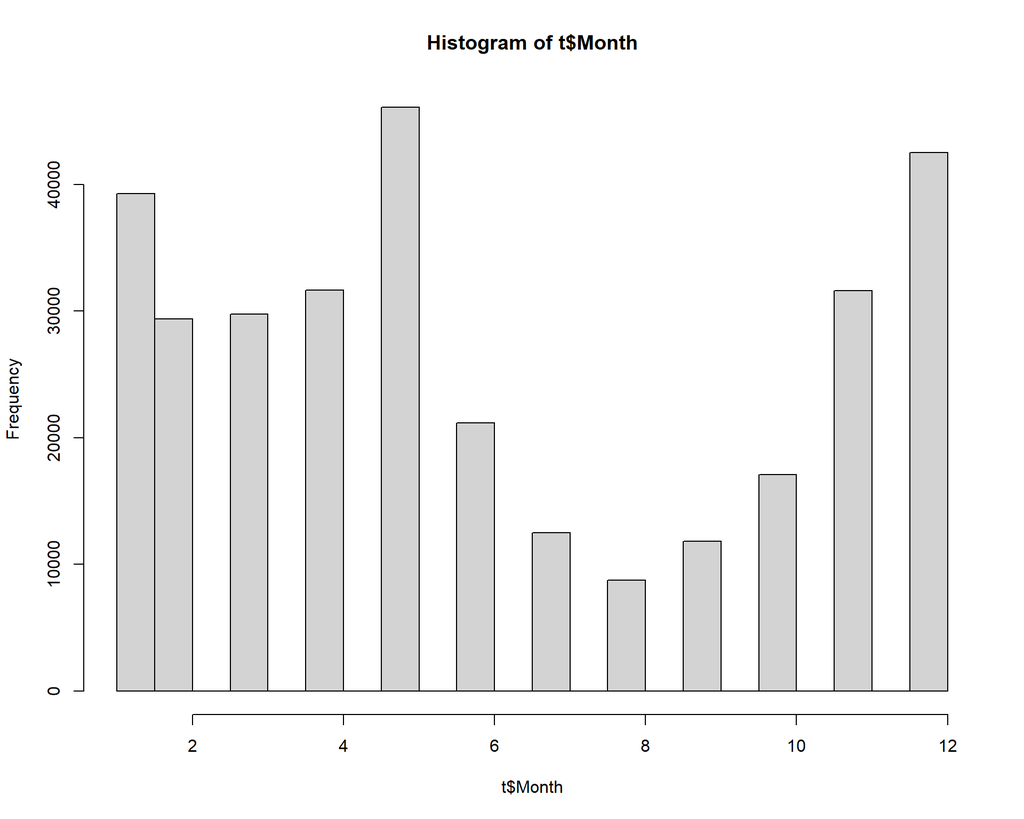

```r
hist(t$Month)
```

```r
table(t$daynightduskdawn.naut)
```

```
#>
#>   dawn    day   dusk  night
#>  32339 171729  23945  93670
```

### 5.6.2 FS95: DVM vs. non-DVM

Figure S13: Cumulated hourly fast starts based on all individuals and time periods for DVM and non-DVM behaviour. Based on a Mann-Whitney test there are significantly more fast starts observed during DVM than during non-DVM behaviour (p= < 2.2e-16). Violin plots in grey represent the full distribution of the data. Boxplot show median and lower and upper quartiles with whiskers extending to 1.5 * IQR.

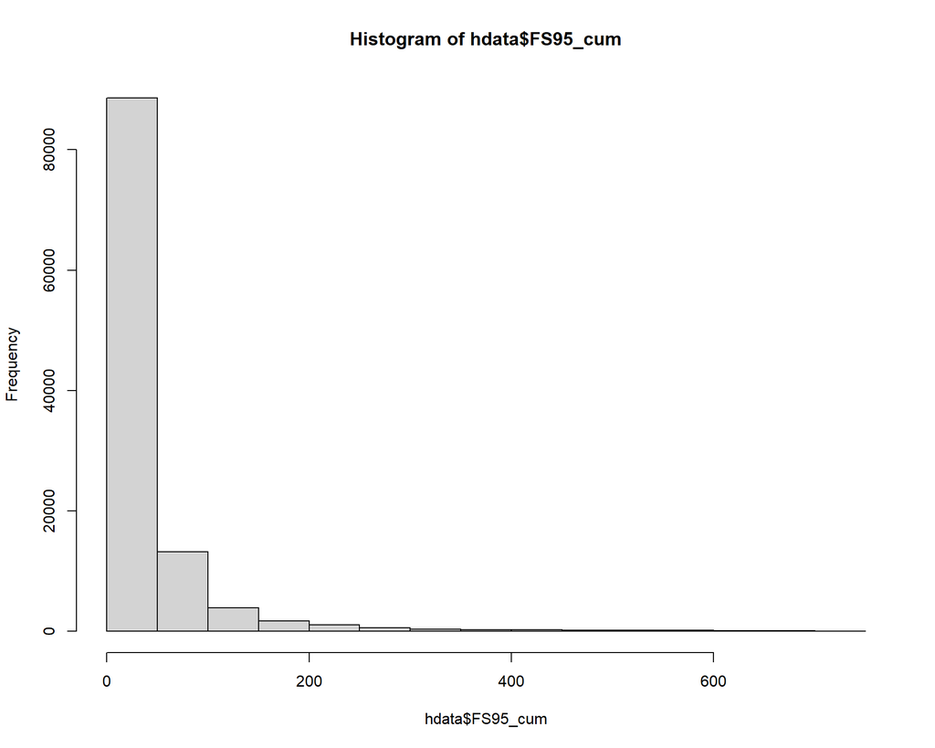

```r
#Non-normally distributed
hist(hdata$FS95_cum)
```

```r
wilcox.test(hdata$FS95_cum ~ hdata$DVM, alternative = "greater")
```

```
#>
#>  Wilcoxon rank sum test with continuity correction
#>
#> data:  hdata$FS95_cum by hdata$DVM
#> W = 1767840970, p-value < 2.2e-16
#> alternative hypothesis: true location shift is greater than 0
```

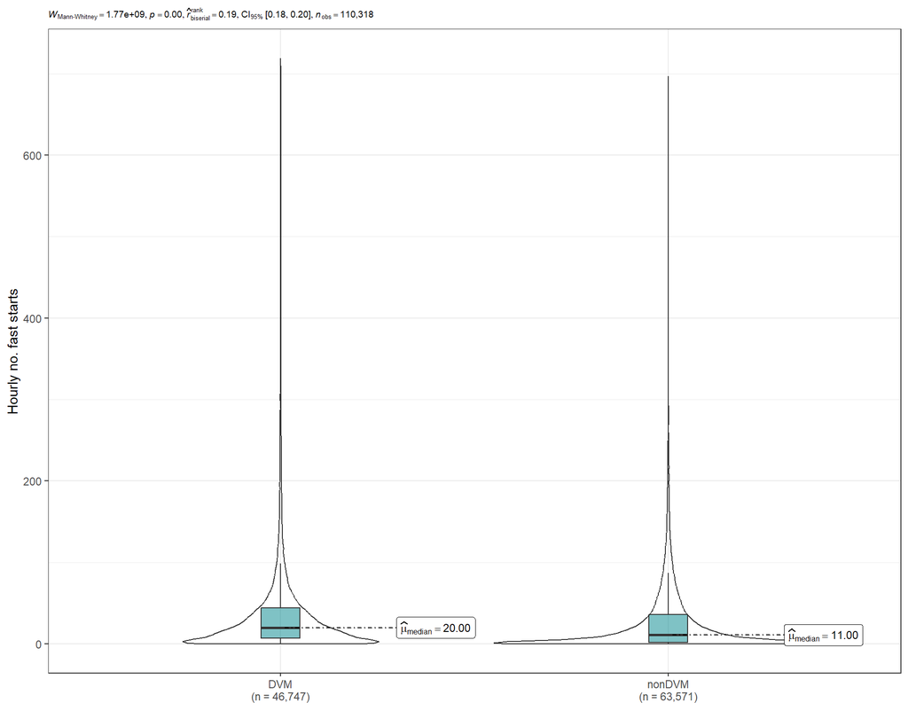

```r
p1 <- ggstatsplot::ggbetweenstats(
  data = hdata,
  x = DVM,
  y = FS95_cum,
  type = "nonparametric",
  boxplot.args = list(width = 0.1, fill = "turquoise4", alpha = 0.5),
  violin.args = list(alpha = 0),
  point.args = list(alpha = 0),
  ggtheme = theme_bw(),
  centrality.point.args = list(alpha = 0),
)
p1 <- p1 + labs(x= "",y = "Hourly no. fast starts")+ theme(plot.subtitle=element_text(size=7, hjust=0, face="italic", color="black"))
p1
```

```r
ggsave(p1, filename = paste0("plots/spurdog/supplement/fig13_FS95_cum-DVMvsnonDVM.png"), width = 12, height = 10, units = "cm")
```

### 5.6.3 FS95: Day vs Night

Figure S14: Median hourly number of fast starts paired for each day and night per individual (A) for as significant DVM classified behaviour and (B) as non-DVM classified behaviour. A paired Wilcoxon signed rank test was performed for both cases, indicating a significantly greater number of fast starts during day (p-value < 2.2e-16, p-value = 2.689e-08). Violin plots in grey represent the full distribution of the data. Boxplot show median and lower and upper quartiles with whiskers extending to 1.5 * IQR.

```r
# DVM
t1 <- hdata %>% filter(DVM == "DVM") %>% group_by(Date, sharkID, daynight) %>% summarise(FScum_median = median(FS95_cum))
t2 <- hdata %>% filter(DVM == "DVM") %>% group_by(Date, sharkID, daynight) %>% summarise(FScum_median = median(FS95_cum)) %>% group_by(Date, sharkID) %>% summarise(n = n())
t <- left_join(t1, t2, by = c("Date", "sharkID")) %>% filter(n == 2) %>% ungroup()
table(t$daynight)
```

```
#>
#>   day night
#>  2024  2024
```

```r
wilcox.test(t$FScum_median ~ t$daynight,paired = TRUE, alternative = "greater")
```

```
#>
#>  Wilcoxon signed rank test with continuity correction
#>
#> data:  t$FScum_median by t$daynight
#> V = 1402560, p-value < 2.2e-16
#> alternative hypothesis: true location shift is greater than 0
```

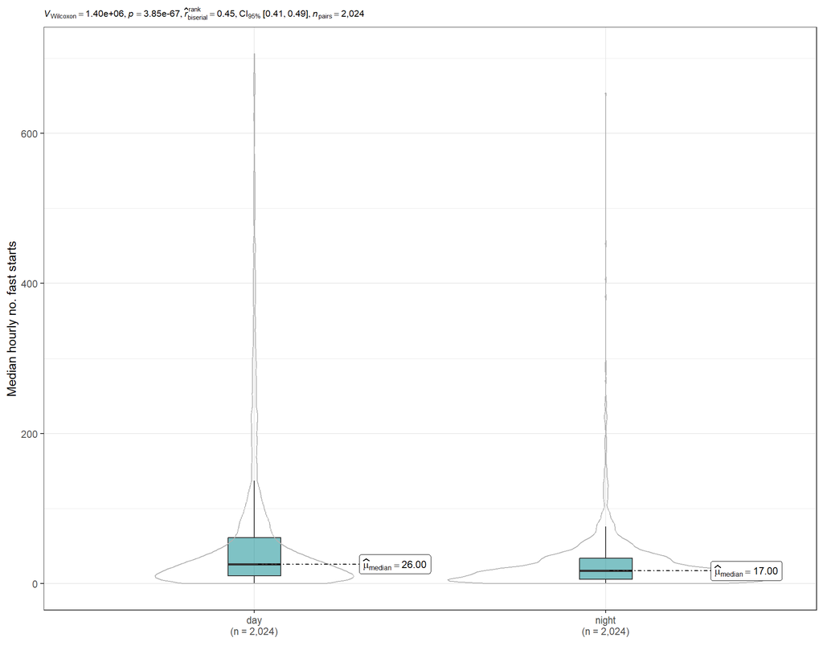

```r
p1 <- ggstatsplot::ggwithinstats( # paired samples
  data = t,
  x = daynight,
  y = FScum_median,
  type = "nonparametric", # for wilcoxon
  boxplot.args = list(width = 0.15, fill = "turquoise4", alpha = 0.5),
  violin.args = list(alpha = 0, colour = "grey70"),
  point.args = list(alpha = 0),# to remove points
  point.path = F,
  ggtheme = theme_bw(),
  centrality.plotting = T,
  centrality.path = F,
  centrality.point.args = list(alpha = 0),
  results.subtitle =T
)
p1 <- p1 + labs(x= "", y = "Median hourly no. fast starts")+ theme(plot.subtitle=element_text(size=8, hjust=0, face="italic", color="black"))
p1
```

```r
# NON DVM
t1 <- hdata %>% filter(DVM == "nonDVM") %>% group_by(Date, sharkID, daynight) %>% summarise(FScum_median = median(FS95_cum))
t2 <- hdata %>% filter(DVM == "nonDVM") %>% group_by(Date, sharkID, daynight) %>% summarise(FScum_median = median(FS95_cum)) %>% group_by(Date, sharkID) %>% summarise(n = n())
t <- left_join(t1, t2, by = c("Date", "sharkID")) %>% filter(n == 2) %>% ungroup()
table(t$daynight)
```

```
#>
#>   day night
#>  2725  2725
```

```r
wilcox.test(t$FScum_median ~ t$daynight,paired = TRUE, alternative = "greater")
```

```
#>
#>  Wilcoxon signed rank test with continuity correction
#>
#> data:  t$FScum_median by t$daynight
#> V = 1588559, p-value = 2.689e-08
#> alternative hypothesis: true location shift is greater than 0
```

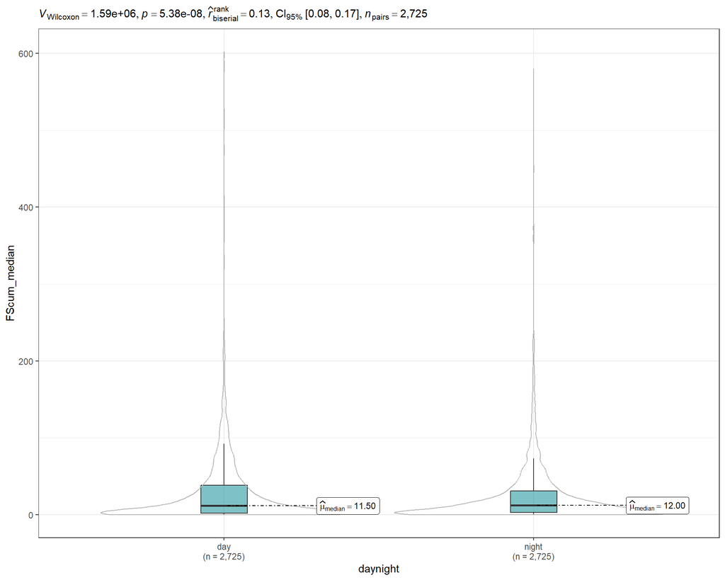

```r
p2 <- ggstatsplot::ggwithinstats( # paired samples
  data = t,
  x = daynight,
  y = FScum_median,
  type = "nonparametric", # for wilcoxon
  boxplot.args = list(width = 0.15, fill = "turquoise4", alpha = 0.5),
  violin.args = list(alpha = 0, colour = "grey70"),
  point.args = list(alpha = 0),# to remove points
  point.path = F,
  ggtheme = theme_bw(),
  centrality.plotting = T,
  centrality.path = F,
  centrality.point.args = list(alpha = 0),
  results.subtitle =T
)
p2
```

```r
p2 <- p2 + labs(x= "", y = "Median hourly no. fast starts")+ theme(plot.subtitle=element_text(size=8, hjust=0, face="italic", color="black"))

p <- (p1|p2) + plot_annotation(tag_levels = 'A')
ggsave(p, filename = paste0("plots/spurdog/supplement/fig14_FS95_cum-DVM_nonDVM_daynight.png"), width = 25, height = 11, units = "cm")
```

Figure S15: Inter-individual differences in median hourly cumulated fast start distributions for day and night. Results from a Wilcoxon signed rank test are shown for each individual shark. Violin plots in grey represent the full distribution of the data. Boxplot show median and lower and upper quartiles with whiskers extending to 1.5*IQR.

```r
# Individual differences
t1 <- hdata  %>% group_by(Date, sharkID, daynight) %>% summarise(FScum_median = median(FS95_cum))
t2 <- hdata  %>% group_by(Date, sharkID, daynight) %>% summarise(FScum_median = median(FS95_cum)) %>% group_by(Date, sharkID) %>% summarise(n = n())
t <- left_join(t1, t2, by = c("Date", "sharkID")) %>% filter(n == 2) %>% ungroup()
table(t$daynight)
```

```
#>
#>   day night
#>  4596  4596
```

```r
p <- ggplot(data = t)+
  geom_boxplot(aes(x = daynight, y = FScum_median),outlier.alpha = 0.3)+
  facet_wrap(~sharkID)+
  theme_bw()+
  labs(x = "",
       y = "Median hourly fast stats")
ggsave(p1, filename = paste0("plots/spurdog/Activity/FS95_cum-DVMvsnonDVM.png"), width = 12, height = 10, units = "cm")


for(s in sharks){
  ts <- t %>% filter(sharkID == s)#
  assign(
    paste0("p",s),
    ggstatsplot::ggwithinstats( # paired samples
      data = ts,
      x = daynight,
      y = FScum_median,
      type = "nonparametric", # for wilcoxon
      boxplot.args = list(width = 0.15, fill = "turquoise4", alpha = 0.5),
      violin.args = list(alpha = 0, colour = "grey70"),
      point.args = list(alpha = 0),# to remove points
      point.path = F,
      ggtheme = theme_bw(),
      centrality.plotting = F,
      centrality.path = F,
      centrality.point.args = list(alpha = 0),
      results.subtitle =T,
      xlab = "",
      ylab  = "Meadian hourly no. fast starts",
      title  = paste0("Shark ", s)
    )
  )
}
p1 <- p1 + theme(plot.subtitle=element_text(size=5.5, hjust=0, face="italic", color="black"))
p2 <- p2 + theme(plot.subtitle=element_text(size=5.5, hjust=0, face="italic", color="black"))
p3 <- p3 + theme(plot.subtitle=element_text(size=5.5, hjust=0, face="italic", color="black"))
p4 <- p4 + theme(plot.subtitle=element_text(size=5.5, hjust=0, face="italic", color="black"))
p5 <- p5 + theme(plot.subtitle=element_text(size=5.5, hjust=0, face="italic", color="black"))
p6 <- p6 + theme(plot.subtitle=element_text(size=5.5, hjust=0, face="italic", color="black"))
p7 <- p7 + theme(plot.subtitle=element_text(size=5.5, hjust=0, face="italic", color="black"))
p8 <- p8 + theme(plot.subtitle=element_text(size=5.5, hjust=0, face="italic", color="black"))
p9 <- p9 + theme(plot.subtitle=element_text(size=5.5, hjust=0, face="italic", color="black"))
p10 <- p10 + theme(plot.subtitle=element_text(size=5.5, hjust=0, face="italic", color="black"))
p11 <- p11 + theme(plot.subtitle=element_text(size=5.5, hjust=0, face="italic", color="black"))
p12 <- p12 +  theme(plot.subtitle=element_text(size=5.5, hjust=0, face="italic", color="black"))
p13 <- p13 + theme(plot.subtitle=element_text(size=5.5, hjust=0, face="italic", color="black"))
p14 <- p14 + theme(plot.subtitle=element_text(size=5.5, hjust=0, face="italic", color="black"))
p15 <- p15 + theme(plot.subtitle=element_text(size=5.5, hjust=0, face="italic", color="black"))
p16 <- p16 +  theme(plot.subtitle=element_text(size=5.5, hjust=0, face="italic", color="black"))
p17 <- p17 +  theme(plot.subtitle=element_text(size=5.5, hjust=0, face="italic", color="black"))
p18 <- p18 +  theme(plot.subtitle=element_text(size=5.5, hjust=0, face="italic", color="black"))
p19 <- p19 +  theme(plot.subtitle=element_text(size=5.5, hjust=0, face="italic", color="black"))
## combining the individual plots into a single plot
p <- ggstatsplot::combine_plots(
  plotlist = list(p1, p2, p3, p4, p5,p6,p7,p8,p9,p10,p11,p12,p13,p14,p15,p16,p17,p18,p19),
  plotgrid.args = list(nrow = 5)
  # annotation.args = list(title = "Individual hourly fast starts over day and night")
)
ggsave(p, filename = paste0("plots/spurdog/supplement/fig15_FS95_cum-Ind_DayNight.png"), width = 35, height = 40, units = "cm")

# FScum_day > FScum_night
for(s in sharks){
  ts <- t %>% filter(sharkID == s)#
  print(s)
  print(wilcox.test(ts$FScum_median ~ ts$daynight,paired = T, alternative = "greater"))
}
```

```
#> [1] 1
#>
#>  Wilcoxon signed rank test with continuity correction
#>
#> data:  ts$FScum_median by ts$daynight
#> V = 11740, p-value = 8.784e-10
#> alternative hypothesis: true location shift is greater than 0
#>
#> [1] 2
#>
#>  Wilcoxon signed rank test with continuity correction
#>
#> data:  ts$FScum_median by ts$daynight
#> V = 9131, p-value = 0.001113
#> alternative hypothesis: true location shift is greater than 0
#>
#> [1] 3
#>
#>  Wilcoxon signed rank test with continuity correction
#>
#> data:  ts$FScum_median by ts$daynight
#> V = 1091.5, p-value = 1
#> alternative hypothesis: true location shift is greater than 0
#>
#> [1] 4
#>
#>  Wilcoxon signed rank test with continuity correction
#>
#> data:  ts$FScum_median by ts$daynight
#> V = 8111, p-value = 0.3169
#> alternative hypothesis: true location shift is greater than 0
#>
#> [1] 5
#>
#>  Wilcoxon signed rank test with continuity correction
#>
#> data:  ts$FScum_median by ts$daynight
#> V = 5879.5, p-value < 2.2e-16
#> alternative hypothesis: true location shift is greater than 0
#>
```

[output cut: 96 more lines]

```
#> [1] 18
#>
#>  Wilcoxon signed rank test with continuity correction
#>
#> data:  ts$FScum_median by ts$daynight
#> V = 24356, p-value < 2.2e-16
#> alternative hypothesis: true location shift is greater than 0
#>
#> [1] 19
#>
#>  Wilcoxon signed rank test with continuity correction
#>
#> data:  ts$FScum_median by ts$daynight
#> V = 13618, p-value = 1
#> alternative hypothesis: true location shift is greater than 0
```

```r
# FScum_day < FScum_night
for(s in sharks){
  ts <- t %>% filter(sharkID == s)#
  print(s)
  print(wilcox.test(ts$FScum_median ~ ts$daynight, alternative = "less"))
}
```

```
#> [1] 1
#>
#>  Wilcoxon rank sum test with continuity correction
#>
#> data:  ts$FScum_median by ts$daynight
#> W = 18679, p-value = 0.9967
#> alternative hypothesis: true location shift is less than 0
#>
#> [1] 2
#>
#>  Wilcoxon rank sum test with continuity correction
#>
#> data:  ts$FScum_median by ts$daynight
#> W = 17453, p-value = 0.9283
#> alternative hypothesis: true location shift is less than 0
#>
#> [1] 3
#>
#>  Wilcoxon rank sum test with continuity correction
#>
#> data:  ts$FScum_median by ts$daynight
#> W = 7343, p-value < 2.2e-16
#> alternative hypothesis: true location shift is less than 0
#>
#> [1] 4
#>
#>  Wilcoxon rank sum test with continuity correction
#>
#> data:  ts$FScum_median by ts$daynight
#> W = 16080, p-value = 0.5244
#> alternative hypothesis: true location shift is less than 0
#>
#> [1] 5
#>
#>  Wilcoxon rank sum test with continuity correction
#>
#> data:  ts$FScum_median by ts$daynight
#> W = 8550.5, p-value = 0.9999
#> alternative hypothesis: true location shift is less than 0
#>
```

[output cut: 96 more lines]

```
#> [1] 18
#>
#>  Wilcoxon rank sum test with continuity correction
#>
#> data:  ts$FScum_median by ts$daynight
#> W = 73494, p-value = 0.9972
#> alternative hypothesis: true location shift is less than 0
#>
#> [1] 19
#>
#>  Wilcoxon rank sum test with continuity correction
#>
#> data:  ts$FScum_median by ts$daynight
#> W = 40461, p-value < 2.2e-16
#> alternative hypothesis: true location shift is less than 0
```

### 5.6.4 FS95: seasonal differences

```r
tpop <- hdata %>% filter(sharkID %in% c(11,12,14,15,17,18,19))
m <- median(tpop$FS95_cum)
m
```

```
#> [1] 8
```

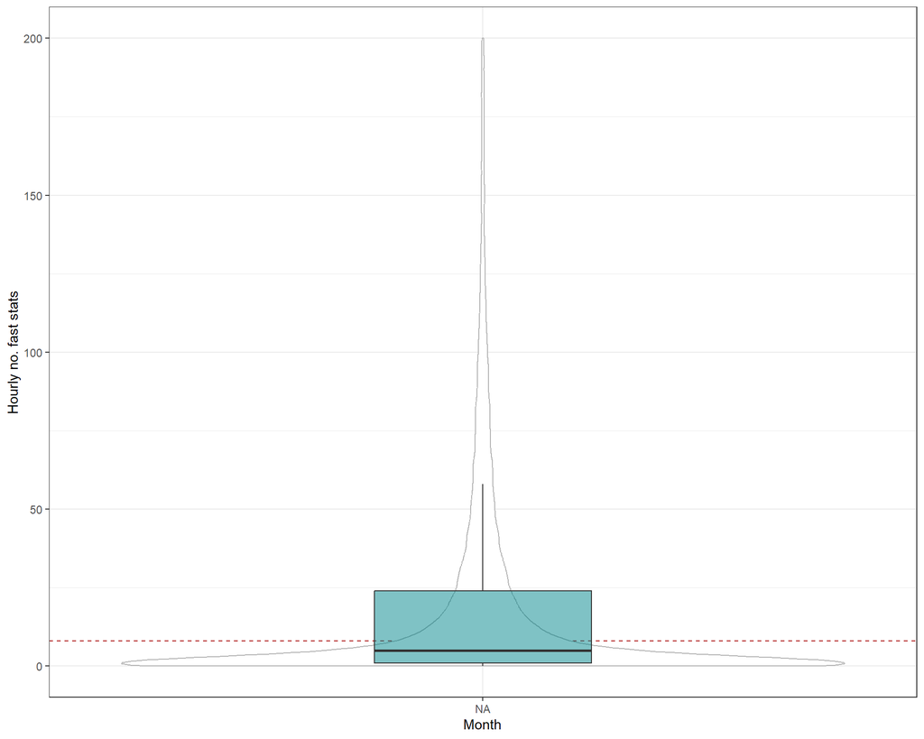

```r
p <- ggplot(data = hdata %>% filter(sharkID %in% c(11,12,14,15)))+
  geom_hline(yintercept = m, colour = "firebrick", linetype = "dashed")+
  geom_violin(aes(x = as.factor(Month), y = FS95_cum), width = 1, alpha = 1, colour = "grey70")+
  geom_boxplot(aes(x = as.factor(Month), y = FS95_cum), outlier.alpha = 0, width = 0.3, fill = "turquoise4", alpha = 0.5)+
  scale_y_continuous(limits = c(0,200))+#trans = "log10")+
  theme_bw()+
  labs(x = "Month",
       y = "Hourly no. fast stats")
p
```

```r
ggsave(p, filename = paste0("plots/spurdog/supplement/fig16_FS95_cum-Season_sharks_11-12_14-15_17-19.png"), width = 15, height = 10, units = "cm")

t <- hdata %>% filter(sharkID %in% c(11,12,14,15,17,18,19) & Month == 10)
median(t$FS95_cum)
```

```
#> [1] NA
```

```r
quantile(t$FS95_cum, p = c(0.25,0.5,0.75))
```

```
#> 25% 50% 75%
#>  NA  NA  NA
```

```r
mean(t$FS95_cum)
```

```
#> [1] NaN
```

```r
tpop <- hdata %>% filter(sharkID %in% c(11,12,14,15,17,18,19))
m <- median(tpop$FS95_cum)
#wilcox.test(x = t$FS95_cum, mu = m, alternative = "greater")
```

### 5.6.5 Environmental effects on FS95

Figure S17: Environmental relationships of light level (A), temperature (B) and depth (C) on the median hourly number of fast starts. Medians of fast starts were taken across bins of 1 light level unit, 0.1°C, and 10m respectively. Bins with n<100 are disregarded. Red line marks a fitted loess function with span = 0.75. 95% confidence intervals shown in grey. A description of how light levels correspond to light intensity is provided in supplementary material above.

```r
# light
t <- hdata %>% mutate(light_bin = cut(Lightlevel_median,
                                   breaks=seq(25,225,1),
                                   labels = FALSE) + 25) %>%
         group_by(light_bin) %>%
         summarise(FS_median = median(FS95_cum),
                   n = n()) %>%
         filter(n>100 & !is.na(light_bin))
cor(t$light_bin, t$FS_median, method = 'pearson')
```

```
#> [1] -0.7943777
```

```r
p1 <- ggplot(data = t,
       aes(x = light_bin, y = FS_median))+
  geom_point()+
  geom_smooth(colour = "firebrick",  linewidth = 0.5,method = "loess",span = 0.75,level = 0.95)+
  theme_bw()+
  labs(x= "Light level", y = "Median hourly no. of fast starts")

# temp
t <- hdata %>%
         mutate(temp_bin = 0.1*cut(Temp_median,
                              breaks=seq(4.5,16.7,0.1),
                              labels = FALSE) + 4.5) %>%
         #select(temp_bin, Temp_median)
         group_by(temp_bin) %>%
         summarise(FS_median = median(FS95_cum),
                   n = n()) %>%
         filter(n>100)
cor(t$temp_bin, t$FS_median, method = 'pearson')
```

```
#> [1] -0.6862214
```

```r
p2 <-ggplot(data = t,
       aes(x = temp_bin, y = FS_median))+
  geom_point()+
  geom_smooth(colour = "firebrick", linewidth = 0.5, method = "loess",span = 0.75,level = 0.95)+
  theme_bw()+
  labs(x= "Temp [\u00B0C]", y = "Median hourly no. of fast starts")


# depth
t <-  hdata %>%
         mutate(depth_bin = 10* cut(Depth_median,
                                   breaks=seq(0,580,10),
                                   labels = FALSE)) %>%
         group_by(depth_bin) %>%
         summarise(FS_median= median(FS95_cum),
                   n = n()) %>%
         filter(n>100)

cor(t$depth_bin, t$FS_median, method = 'pearson')
```

```
#> [1] 0.8359333
```

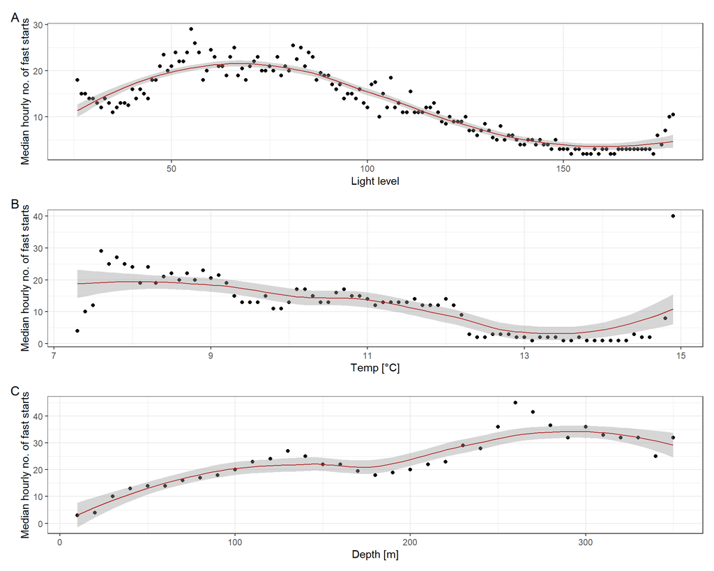

```r
p3 <-ggplot(data =t, aes(x = depth_bin, y = FS_median))+
  geom_point()+
  geom_smooth(colour = "firebrick", linewidth = 0.5, method = "loess",span = 0.75,level = 0.95)+
  theme_bw()+
  labs(x= "Depth [m]", y = "Median hourly no. of fast starts")
p <- p1/p2/p3 + plot_annotation(tag_levels = 'A')

ggsave(p, filename = paste0("plots/spurdog/supplement/fig17_FS95_Light_Temp_Depth.png"), width = 15, height = 25, units = "cm")
p
```